# list

```julia
using JuMP
using HiGHS
using Plots
using JuMP
using HiGHS
using LinearAlgebra
```

## Problema 1

a) Problema da mochila

b) $$(0,0,0) => 0$$ $$(0,0,1) => 3$$ $$(0,1,0) => 4$$ $$(0,1,1) => 7$$ $$(1,0,0) => 6$$ $$(1,0,1) => -\infty$$ $$(1,1,0) => -\infty$$ $$(1,1,1) => -\infty$$ $$x^*=(0,1,1) \quad z^*=7$$

c) O problema relaxado perde as restrições de integralidade: $$ \begin{aligned} &\max && 6x_1 +4x_2 + 3x_3 \\ & st && 6x_1 +5x_2 + 5x_3 \leq 10\\ &&& x_1 \in [0,1] \\ &&& x_2 \in [0,1] \\ &&& x_3 \in [0,1] \\ \end{aligned} $$

Agora podemos usar uma certa "densidade de ganho": $$ \begin{aligned} &\max && y_1 +\frac{4}{5}y_2 + \frac{3}{5}y_3 \\ & st && y_1 +y_2 + y_3 \leq 10\\ &&& y_1 \in [0,6] \\ &&& y_2 \in [0,5] \\ &&& y_3 \in [0,5] \\ \end{aligned} $$ Agora, usando ordem de mérito temos $y^*=[6,4,0]$ que equivale à $x^*=[1,\frac{4}{5},0]$ e $UB=9.2$

d) $gap = UB - z^* = 9.2 - 7 = 2.2$

e) $$ \begin{aligned} &\max && 6x_1 +4x_2 + 3x_3 \\ & st && 6x_1 +5x_2 + 5x_3 \leq 10 & :\lambda\\ &&& x_1 \in [0,1] \\ &&& x_2 \in [0,1] \\ &&& x_3 \in [0,1] \\ \end{aligned} $$ Dual Lagrangiana: $$ \begin{aligned} &\max && 6x_1 +4x_2 + 3x_3 + \lambda (6x_1 +5x_2 + 5x_3 - 10)\\ & st && x_1 \in [0,1]\\ &&& x_2 \in [0,1] \\ &&& x_3 \in [0,1] \\ \end{aligned} $$ Separando: $$ z_1 = \begin{aligned} &\max && 6x_1 + \lambda 6x_1\\ & st && x_1 \in [0,1]\\ \end{aligned} $$ $$ z_2 = \begin{aligned} &\max && 4x_2 + \lambda 5x_2\\ & st && x_2 \in [0,1]\\ \end{aligned} $$ $$ z_3 = \begin{aligned} &\max && 3x_3 + \lambda 5x_3\\ & st && x_3 \in [0,1]\\ \end{aligned} $$

Resolvendo cada um dos problemas: $$z_1 = 6+6\lambda \quad \text{se $\lambda \geq - 1$}$$ $$z_1 = 0 \quad \text{se $\lambda < - 1$}$$

Juntando temos que a função lagrangiana vale:

$$g(\lambda) = -10\lambda \quad \text{se $\lambda < - 1$}$$$$g(\lambda) = 6-4\lambda \quad \text{se $-1 \leq \lambda < - \frac{4}{5}$}$$$$g(\lambda) = 10+\lambda \quad \text{se $-\frac{4}{5} \leq \lambda<-\frac{3}{5}$}$$$$g(\lambda) = 13+6\lambda \quad \text{se $\lambda \geq - \frac{3}{5}$}$$

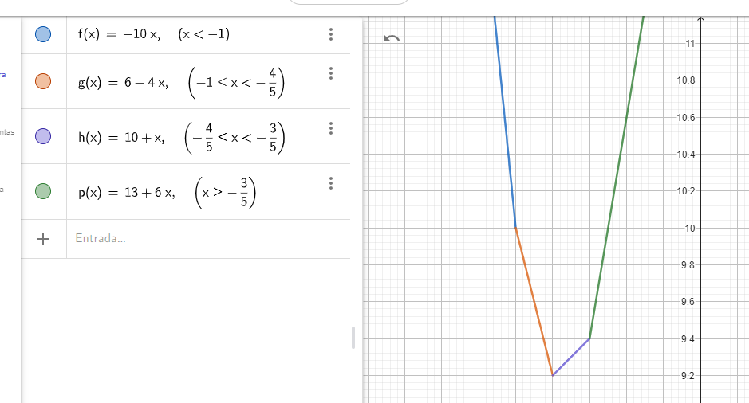

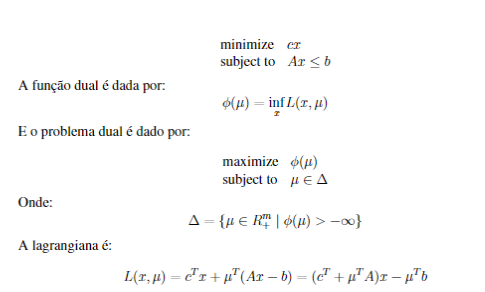

g)

```julia
c = [6,4,3]
v = [6,5,5]
V = 10

function dual(λ)
    m = Model(HiGHS.Optimizer)
    set_silent(m)
    @variable(m, 0 <= x[1:3] <= 1)
    @objective(m, Max, c'x - λ*(v'x-V))
    optimize!(m)
    return objective_value(m), V-v'value.(x)
end

function subgradient(x, maxiter)
    fs = []
    for i = 1:maxiter
        f, df = dual(x)
        push!(fs, f)
        x = x - 0.05*(0.9)^(i-1)*df
    end
    return fs
end

maxiter = 100
fs = subgradient(0,maxiter);
plot(1:maxiter,fs, xlabel="Iterações", label="subgradient")
plot!(1:maxiter, repeat([9.2],maxiter), label="9.2")
```

[figure not shown]

i)

```julia
function cutting_planes(x, axiter)
    fs = []
    model = Model(HiGHS.Optimizer)
    set_silent(model)
    @variable(model, y)
    @variable(model, d)
    @objective(model, Min, d)
    for iter = 1:maxiter
        f, df = dual(x)
        @constraint(model, d >= f + dot(df,y - x))
        optimize!(model)
        x = value.(y)
        push!(fs, f)
    end
    return fs
end

maxiter=100
fs = cutting_planes(0,maxiter)
plot(1:maxiter,fs, xlabel="Iterações", label="cutting_planes")
plot!(1:maxiter, repeat([9.2],maxiter), label="9.2")
```

[figure not shown]

## Problema 2

a) $$ \begin{aligned} &\min && \Sigma_{i \in U}c_ig_i + \Sigma_{c \in J^C}z_cI_c \\ & st && \Sigma_{j \in U_i}c_j + \Sigma_{l \in \delta^0(i)}f_l +\Sigma_{c \in \Delta^0(i)}f_c - \Sigma_{l \in \delta^d(i)}f_l -\Sigma_{c \in \Delta^d(i)}f_c = d_ih & \forall i \in B\\ &&& -F_lh \leq f_l \leq F_lh & \forall l \in L^{Ex}\\ &&& -F_cz_ch \leq f_c \leq F_cz_ch & \forall c \in L^{C}\\ &&& 0 \leq g_i \leq P_ih & \forall i \in U\\ &&& z_c \in \{0,1 \} & \forall c \in L^{C}\\ \end{aligned} $$

b) $$ \begin{aligned} &\min && \Sigma_{i \in U}c_ig_i + \Sigma_{c \in J^C}z_cI_c \\ & st && \Sigma_{j \in U_i}c_j + \Sigma_{l \in \delta^0(i)}f_l +\Sigma_{c \in \Delta^0(i)}f_c - \Sigma_{l \in \delta^d(i)}f_l -\Sigma_{c \in \Delta^d(i)}f_c = d_ih & \forall i \in B\\ &&& f_l = \frac{1}{x_l}(\theta_{o(l)} - \theta_{d(l)}) & \forall l \in L^{Ex}\\ &&& f_c = \frac{z_c}{x_c}(\theta_{o(c)} - \theta_{d(c)}) & \forall c \in L^{C}\\ &&& -F_lh \leq f_l \leq F_lh & \forall l \in L^{Ex}\\ &&& -F_cz_ch \leq f_c \leq F_cz_ch & \forall c \in L^{C}\\ &&& 0 \leq g_i \leq P_ih & \forall i \in U\\ &&& z_c \in \{0,1 \} & \forall c \in L^{C}\\ \end{aligned} $$

c) $$ \begin{aligned} &\min && \Sigma_{i \in U}c_ig_i + \Sigma_{c \in J^C}z_cI_c \\ & st && \Sigma_{j \in U_i}c_j + \Sigma_{l \in \delta^0(i)}f_l +\Sigma_{c \in \Delta^0(i)}f_c - \Sigma_{l \in \delta^d(i)}f_l -\Sigma_{c \in \Delta^d(i)}f_c = d_ih & \forall i \in B\\ &&& f_l = \frac{1}{x_l}(\theta_{o(l)} - \theta_{d(l)}) & \forall l \in L^{Ex}\\ &&& f_c = \frac{z_k}{x_c}(\theta_{o(c)} - \theta_{d(c)}) & \forall c \in L^{C,Conj}_k, k \in K^{Conj}\\ &&& -F_lh \leq f_l \leq F_lh & \forall l \in L^{Ex}\\ &&& -F_cz_kh \leq f_c \leq F_cz_kh & \forall c \in L^{C,Conj}_k, k \in K^{Conj}\\ &&& 0 \leq g_i \leq P_ih & \forall i \in U\\ &&& z_c \in \{0,1 \} & \forall c \in L^{C}\\ \end{aligned} $$

d) $$ \begin{aligned} &\min && \Sigma_{i \in U}c_ig_i + \Sigma_{c \in J^C}z_cI_c \\ & st && \Sigma_{j \in U_i}c_j + \Sigma_{l \in \delta^0(i)}f_l +\Sigma_{c \in \Delta^0(i)}f_c - \Sigma_{l \in \delta^d(i)}f_l -\Sigma_{c \in \Delta^d(i)}f_c = d_ih & \forall i \in B\\ &&& f_l = \frac{1}{x_l}(\theta_{o(l)} - \theta_{d(l)}) & \forall l \in L^{Ex}\\ &&& f_c = \frac{z_c}{x_c}(\theta_{o(c)} - \theta_{d(c)}) & \forall c \in L^{C}\\ &&& \Sigma_{c \in L^{CME}_k} z_c = 1 & \forall k \in K^{ME}\\ &&& -F_lh \leq f_l \leq F_lh & \forall l \in L^{Ex}\\ &&& -F_cz_ch \leq f_c \leq F_cz_ch & \forall c \in L^{C}\\ &&& 0 \leq g_i \leq P_ih & \forall i \in U\\ &&& z_c \in \{0,1 \} & \forall c \in L^{C}\\ \end{aligned} $$

e) $$ \begin{aligned} &\min && \Sigma_{i \in U}c_ig_i + \Sigma_{c \in J^C}z_cI_c \\ & st && \Sigma_{j \in U_i}c_j + \Sigma_{l \in \delta^0(i)}f_l +\Sigma_{c \in \Delta^0(i)}f_c - \Sigma_{l \in \delta^d(i)}f_l -\Sigma_{c \in \Delta^d(i)}f_c = d_ih & \forall i \in B\\ &&& f_l = \frac{1}{x_l}(\theta_{o(l)} - \theta_{d(l)}) & \forall l \in L^{Ex}\\ &&& f_c = \frac{z_k}{x_c}(\theta_{o(c)} - \theta_{d(c)}) & \forall c \in L^{C,Conj}_k, k \in K^{Conj}\\ &&& \Sigma_{k \in K^{ME}} z_k = 1 \\ &&& -F_lh \leq f_l \leq F_lh & \forall l \in L^{Ex}\\ &&& -F_cz_kh \leq f_c \leq F_cz_kh & \forall c \in L^{C,Conj}_k, k \in K^{Conj}\\ &&& 0 \leq g_i \leq P_ih & \forall i \in U\\ &&& z_c \in \{0,1 \} & \forall c \in L^{C}\\ \end{aligned} $$

## Problema 3

a) Não consegui realizar essa demonstração, deixei aqui um print do livro que contém a demonstração, sendo a implecação c=>a

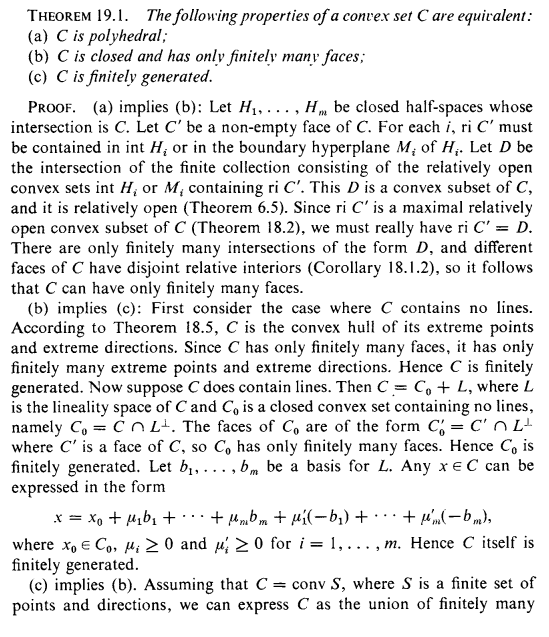

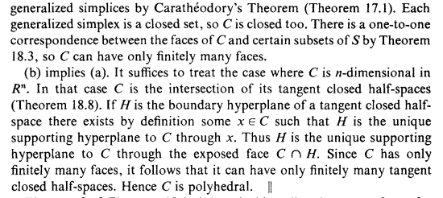

b) Um ponto $x$ de um conjunto convexo $A$ é dito extremo, se e somente se, não pode ser representado como uma combinação convexa estrita de dois pontos distintos de $A$.  
Os ponto de $Conv(X)$ são as combinação convexa dos pontos de $X$.  
Se $x$ é ponto extremo de $Conv(X)$, a unica combinação convexa dos pontos de $Conv(X)$ que geram $x$ é $1x$. Como $x$ percente a $Conv(X)$, $x$ é combinação convexa dos pontos de $X$. Mas como $X$ esta contido em $Conv(X)$, a unica combinação convexa possivel de $x$ em $X$ é $1x$, ou seja, $x$ pertence a $X$.

## Problema 4

Nesta questão $z_i$ representara uma varaivel binaria que vale 1 se o investimento $i$ for escolhido e 0 se ele não for escolhido. $w_j$ sera utilizada para modelar a escolha de um grupo.

a) $$x_1 + x_2 + x_3 + x_4 + x_5 + x_6 + x_7 \leq K$$

b) $$x_1 + x_2 + x_3 + x_4 + x_5 + x_6 + x_7 \geq 1$$

c) $$x_1 + x_3 \leq 1$$

d) $$x_2 \geq x_4$$

e) $$x_1 + x_5 \geq 1$$

f) $$w_1 \leq z_1 $$ $$w_1 \leq z_2 $$ $$w_1 \leq z_3 $$ $$w_2 \leq z_2 $$ $$w_2 \leq z_4 $$ $$w_2 \leq z_5 $$ $$w_2 \leq z_6 $$ $$w_1 + w_2 \geq 1 $$

## Problema 5

a) Começamos com $u=zx_1+(1-z)x_2$, onde $z$ é binária. Assim $z$ irá escolher entre $x_1$ e $x_2$. Para garantir que esse escolha será correta precisamos adicionar $zx_1 \leq x_2$ e $(1-z)x_2 \leq x_1$. Desta forma $z$ irá precisar zerar a maior das duas variáveis para ser viável. Basta simplesmente linearizar os produtos (Descrito melhor na questão 16). Por fim para $y_1=zx_1$ e $y_2=(1-z)x_2$ temos:
$$u=y_1+y_2$$
$$y_1 \leq x_2$$
$$y_2 \leq x_1$$
Linearização de $y_1=zx_1$:
$$y_1 \leq zC_1$$
$$y_1 \leq x_1$$
$$y_1 \geq x_1 - C_1(1-z)$$
$$y_1 \geq 0$$
Linearização de $y_2=(1-z)x_2$:
$$y_2 \leq (1-z)C_2$$
$$y_2 \leq x_2$$
$$y_2 \geq x_2 - zC_2$$
$$y_2 \geq 0$$

c) Para começar podemos construir hiperplanos em $\mathbb{R}^n$ para isolar o ponto $x^*$. Sendo eles: $$ x_i \geq x^*_i + \delta \forall i \in {1, 2..., n}$$ $$ x_i \leq x^*_i - \delta \forall i \in {1, 2..., n}$$

Onde $\delta \in ]0,1]$, pode ser escolhido como 0.5, por exemplo. Mas escolher igual a 1 gera uma relaxação mais apertada. Pela restrição de integraldiade, $x^*$ é o unico ponto excluido por todas essas restrições. Qualquer outro ponto pode violar pelo menos uma delas. Agora basta garantir que pelo menos 1 delas estara ativa, introduzindo variaveis binarias temos:

$$ x_i \geq x^*_i + \delta - M z_i^+ \forall i \in {1, 2..., n}$$$$ x_i \leq x^*_i - \delta + M z_i^-\forall i \in {1, 2..., n}$$$$\Sigma z_i^+ + \Sigma z_i^- \leq 2n-1 $$

As duas primeiras restrições são relaxadas quando o respectivo $z$ vale 1, para isso é necessario extimar um BigM. A ultima restrição diz que pelo menos uma das restrições deve permacenar ativa, isso exclui apenas $x^*$.

## Problema 6

a) Sendo $x$ a quantidade de armarios, $y$ a quantiade de berços, $z$ a variavel de decisão de expansão e $C$ o custo de expandir: $$ \begin{aligned} &\max && 4x +3y - Cz \\ & st && (2-z)x +(1-0.9z)y \leq 4\\ &&& (1-0.6z)x +(2-z)y \leq 4\\ &&& z \in \{ 0,1\} \end{aligned} $$

## Problema 7

Sendo $w$ o vetor de custo de investimento e $M$ uma constante suficientemente grande $$ \begin{aligned} &\max && c^Tx-w^Tz \\ & st && A_ix \leq b_i + (1-z_i)M & \forall i \in {1,2...,K}\\ &&& \Sigma_{i=1}^K z_i = 1\\ \end{aligned} $$

## Problema 8

Todas as 16 possibilidades foram avaliadas para cada uma das restrições. Uma intercessão foi feita para as ultimas 3, obtendo uma mesma tabela verdade.

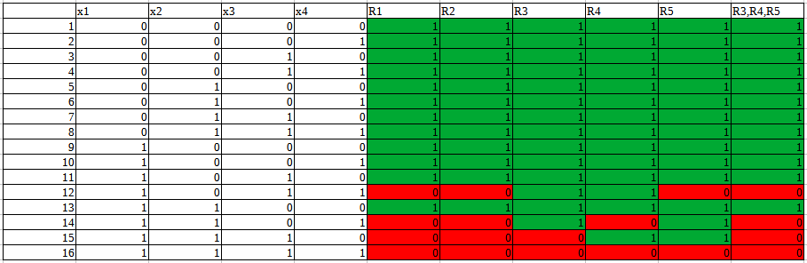

## Problema 9

$$ \begin{aligned} &\min && \Sigma_{ij \in A} c_{ij}x_{ij} \\ & st && \Sigma_j x_{ij} - \Sigma_j x_{ji} = 1 & i=s\\ &&& \Sigma_j x_{ij} - \Sigma_j x_{ji} = -1& i=t\\ &&& \Sigma_j x_{ij} - \Sigma_j x_{ji} = 0 & otherwise\\ &&& x_{ij} \in \{ 0,1\} & \forall ij \in A \end{aligned} $$

$ij$ representa a aresta de conexão dos vértice $i$ para vértice $j$. $A$ é o conjunto de arrestas. $s$ é o ponto de partica e $t$ o ponto de chegada. $x_{ij}$ é 1 se a aresta foi usada e 0 caso contrario. Sendo assim, a primeira restrição indica que o vértice de partida deve ter uma saida a mais que entradas. A segunda restrição indica que o vértice de chegada deve ter uma saida a menos que entradas. A terceira restrição indica que os outros vértices devem ter o mesmo numero de saidas e entradas.

A matriz do problema possui $n$ linhas e $n^2$ colunas, onde $n$ é o numero de vértices. Analisando as restrições é facil ver que as colunas são nulas ou possuem exatamente um numero $1$ e um numero $-1$. Usando esses fator vamos mostrar que ela é totalmente unimodular. Lembrando que queremos mostrar que qualquer submatrix quadrada não tem inversa ou é unimodular. Como os coeficiente da matriz são 0, 1 ou -1, basta mostrar que as submatrizes tem determinante 0 (não tem inversa), 1 (unimodular) ou -1 (unimodular).

Relembrando a definição de determinante. Seja um funcional linear em matrizes quadradas com as seguintes propriedades:

1. $F(x_1, ... ,x_i, ...,x_j, ...,x_n) = -F(x_1, ... ,x_j, ...,x_i, ...,x_n)$ Troca linhas ou colunas muda o sinal
2. $F(x_1, ... ,kx_i, ...,x_n) = kF(x_1, ..., x_i, ...,x_n)$ Multiplicar uma linha ou coluna por um numero, multiplica o funcional
3. $F(x_1, ... ,x_i, ...,x_j, ...,x_n) = F(x_1, ... ,x_i + kx_j, ...,x_j, ...,x_n)$ Somar multiplos de uma linha ou coluna, respectivamente, em outra linha ou coluna, não altera o funcional

Esse funcional é unico e chamamos ele de determinante (Algebra Linear - Elon Lages, IMPA.)

Com essas propriedades, podemos construir um algoritmo para calcular o determinante:

1. Escalone a matriz até ficar triangular, anotando as operações
2. O determinante da matriz triangular é o produto da diagonal principal
3. Usando as anotações das operações durante o escalonamento e as propriedades do determinante, recupere o determinante da matriz original

A matriz de nosso interesse so possui 1 e -1 para serem eliminados no escalonamento. Como cada coluna so possui no maximo um 1 e um -1, ao somar uma linha na outra, teremos as operações 0+0, 1+0, -1+0 e -1+1. Todas essas operações produzem 0, 1 ou -1. Ou seja, podemos escalonar a matriz apenas somando linhas umas nas outras (não altera o determinante) ou trocar linhas de lugar (muda o sinal do determinante), sem criar nenhum numero diferente de 0,1 e -1. Ao final do escalonamento, a diagonal principal contera apenas 0, 1 e -1. Ou seja o determinante sera 0, 1 ou -1. No maximo o sinal devera ser trocado (devido a trocas de linhas durante o escalonamento), mas permanecera como 0, 1 ou -1. Logo a matriz do problema é totalmente unimodular.

Em relação ao algoritmo, como as matriz é totalmente unimodular, todas as bases usadas ao longo do simplex são unimodulares, ou seja, vão produzir uma solução inteira (pois o RHS é inteiro). Logo podemos relaxar as restrições de integralidade.

## Problema 10

Seja $x_{ij}$ uma variavel binaria que vale $1$ se uma rainha esta na linha $i$, coluna $j$ e $0$ caso contrario. Como esse é um problema de viabilidade, a função objetivo e o sentivo da otimização são irrelevantes, podemos escolher por exemplo minimizar $0$.

Para cada coluna, pode existir no maximo 1 rainha: $$ \Sigma_{i=1}^N x_{ij} \leq 1 \quad \forall j \in {1,2..,N} $$

Para cada linha, pode existir no maximo 1 rainha: $$ \Sigma_{j=1}^N x_{ij} \leq 1 \quad \forall i \in {1,2..,N} $$

Para as diagonais, podemos construir os conjuntos auxiliares de diagonais noroete -> sudeste: $$ d_k^- = \{ (i,j) | i+j=k \quad \forall i \in {1,2...,N}\forall j \in {1,2...,N} \} $$ E diagonais sudoeste->nordeste: $$ d_k^+ = \{ (i,j) | i-j=k \quad \forall i \in {1,2...,N}\forall j \in {1,2...,N} \} $$

Sendo assim temos: $$ \Sigma_{i,j \in d_k^-} x_{ij} \leq 1 \quad \forall k \in {3,4..,2N-1} $$ $$ \Sigma_{i,j \in d_k^+} x_{ij} \leq 1 \quad \forall k \in {2-N,1-N..,2N-2} $$

## Problema 11

a) Se PI é inviavel, $z=-\infty$, logo a desigualdade é trivial. Se PI tem solução $x^*$, $x^*$ pertence a $T$, pois $x^*$ pertence a $X$ e $X$ esta contido em $T$. Além disso, $f(x^*) \geq c(x^*)$, logo $z^R \geq f(x^*) \geq c(x^*) = z$. Se PI é ilimitado, PR também sera ilimitado por conter a mesma direção extrema.

b) Como o conjunto viavel de $P_1$ esta contido no conjunto viavel de $P_2$ e eles possuem a mesma função objetivo, temos que $P_2$ é uma relaxação de $P_2$, logo pelo item (a) temos a conclusão desejada.

c) Se PR é inviavel, $z^R = -\infty$, logo $z \leq z^R = -\infty$, o que implica que $z = -\infty$, logo PI é inviavel.

d) Pela propridade da relaxação temos que $z^R \geq z$, por hipotese do enunciado $f(x^*) = c(x^*)$, logo: $c(x^*) = f(x^*) = z^R \geq z \geq c(x^*)$. Logo $z = c(x^*)$, o que implica que x^* também é ponto otimo de PI.

## Problema 12

Assumindo que problemas de maximização inviáveis tem valor ótimo menos infinito e problemas de maximização ilimitados tem valor ótimo infinito (Usando reta real extendida). Quando o primeiro problema é inviável, $z$ é menos infinito, então teremos $z(u) \geq z$. Em outros casos, perceba que para todo $x$ viável no primeiro problema temos $z \geq c^Tx$. Como o segundo problema tem menos restrições, para todo $x$ viável no primeiro problema ele também é viável no segundo problema. Temos que $z(u) \geq c^Tx + u^T(b-Ax)$. Como estamos supondo que $x$ é viável, então $b-Ax$ tem todas as coordenadas não negativas, como por hipótese $u$ tem todas as coordenadas não negativas, $u^T(b-Ax)$ é não negativo. Sendo assim, se o primeiro problema é ilimitado, o segundo também é e vale $z(u) \geq z$. Se o primeiro problema tem solução ótimo $x^*$, então temos $z(u) \geq c^Tx^* + u^T(b-Ax^*) \geq c^Tx^* = z$.

## Problema 13

Perceba que (D) é um problema de programação linear e que seu dual, chamado aqui de (P), é $max\{c^Tx | Ax \leq b x \in \mathbb{R}^n_+\}$. Perceba também que (P) é uma relaxação de (PI), uma vez que a única diferença entre eles é que (P) possui variáveis reais e que (PI) possui variáveis inteiras. Por dualidade forte da programação linear, temos que $z_D = z_P$. Por ser relaxação, temos que $z_P \geq z_{PI}$, então $z_D = z_P \geq z_{PI}$. Além disso como (D) é um problema de minimização, se ele é ilimitado, $z_D = - \infty$, então $z_{PI} = - \infty$, mas como (PI) é um problema de maximização, isso significa ser inviável.

## Problema 14

A única diferença entrer $P_1$ e $P_2$ está nas restrições, sendo assim, basta mostrar que o conjunto viável de $P_1$ está contido em $P_2$. Mais precisamente, a diferença é que em $P_1$ temos $Ax=b$ e em $P_2$ temos $u^TAx=u^Tb$, que é equivalente à $u^T(Ax-b)=0$, que claramente é verdade quando $Ax=b$. Sendo assim, $P_2$ é relaxação de $P_1$.

## Problema 16

Sendo $lb_x$ e $ub_x$ os bounds de $x$, podemos discretizar fazendo: $x = lb_x + \Sigma_{n=1}^N \frac{ub_x-lb_x}{N} w_i$, onde $w_i$ são binarias. Temos então $xy = ylb_x + \Sigma_{i=1}^N \frac{ub_x-lb_x}{N} yw_i$. Agora so existem produtos entre varaiveis continuas e binarias, podemos usar a mesma tecnica para todas.

O produto $yz$, podemos inserir $t$ e um numero suficientemente grande $M$: $-M(1-z) \leq t-y \leq M(1-z)$ e $-Mz \leq t \leq Mz$.

O produto $yw_i$, podemos inserir $r_i$ e um numero suficientemente grande $M$: $-M(1-w_i) \leq r_i-y \leq M(1-w_i)$ e $-Mw_i \leq r_i \leq Mw_i$ $\forall i \in \{ 1,2...,N\}$.

## Problema 17

Seja $x_{ijk}$ binária com $x_{ijk} = 1$ se número $k$ está na linha $i$ e coluna $j$ e $x_{ijk} = 0$ caso contrário. Cada célula precisa de um número: $$ \Sigma_{k=1}^9 x_{ijk} = 1 \quad \forall i \in {1,...,9}, j \in {1,...,9} $$ Cada linha precisa conter um exemplar de cada numero: $$ \Sigma_{j=1}^9 x_{ijk} = 1 \quad \forall i \in {1,...,9}, k \in {1,...,9} $$ Cada coluna precisa conter um exemplar de cada numero: $$ \Sigma_{i=1}^9 x_{ijk} = 1 \quad \forall j \in {1,...,9}, k \in {1,...,9} $$ Blocos 3x3 precisam conter um exemplar de cada numero: $$ \Sigma_{i=3b_i-2}^{3b_i}\Sigma_{j=3b_j-2}^{3b_j} x_{ijk} = 1 \quad \forall b_i \in {1,2,3}, b_j \in {1,2,3}, k \in {1,...,9} $$ Valores inicais num conjunto $P$: $$ x_{ijk} = 1 \quad \forall ijk \in P $$

```julia
model = Model(HiGHS.Optimizer)
set_silent(model)
@variable(model, x[1:9,1:9,1:9], Bin)
@constraint(model, [i = 1:9, j = 1:9], sum(x[i,j,:]) == 1)
@constraint(model, [i = 1:9, k = 1:9], sum(x[i,:,k]) == 1)
@constraint(model, [j= 1:9, k = 1:9], sum(x[:,j,k]) == 1)
@constraint(model, [bi = 1:3, bj = 1:3, k = 1:9], sum(x[i,j,k] for i = 3bi-2:3bi, j = 3bj-2:3bj) == 1)
P =
[
0 0 0 0 1 0 9 0 2
0 3 0 0 0 7 0 8 0
0 0 0 3 6 0 7 0 0
0 0 0 2 0 0 1 0 3
0 5 0 0 0 0 0 7 0
1 0 4 0 0 3 0 0 0
0 0 3 0 4 6 0 0 0
0 8 0 9 0 0 0 4 0
5 0 6 0 8 0 0 0 0
];
P = [(i,j,k) for i in 1:9, j in 1:9, k in 1:9 if P[i,j] == k]
@constraint(model, [(i,j,k) in P], x[i,j,k] == 1)
optimize!(model)
x = value.(x)
sol = zeros(Int, 9, 9)
for i in 1:9, j in 1:9, k in 1:9
    if round(Int, x[i, j, k]) == 1
        sol[i, j] = k
    end
end
sol
```

```
9×9 Matrix{Int64}:
 6  7  5  4  1  8  9  3  2
 4  3  9  5  2  7  6  8  1
 2  1  8  3  6  9  7  5  4
 8  9  7  2  5  4  1  6  3
 3  5  2  6  9  1  4  7  8
 1  6  4  8  7  3  5  2  9
 9  2  3  7  4  6  8  1  5
 7  8  1  9  3  5  2  4  6
 5  4  6  1  8  2  3  9  7
```

## Problema 18

O TSP pede como solução um ciclo. A MST tem como solução uma arvore, vamos ver então como é possivel a partir da arvore do MST, gerar um ciclo para o TSP:

1. Remova um vértice $i$ do grafo e resolva MST, obtendo a arvore T.
2. Devolva o vértice removido para o grafo e escolha outros 2 vértices distintos $j$ e $k$. Adicione na arvore T arestas $ij$ e $ik$, obtendo o grafo G.
3. Começando por $i$, percorra os vertices pelas arestas possiveis, sempre que seja necessario, "pule" um vértice ja visitado. Assim obtera um caminho.
4. Volte para o vértice $i$, obtendo um caminho

Ao final desses passos, visitamos todos os vértives, uma vez que todos os vértives estavam conexos pela arvore e pelas arestas adicionais. Sendo assim é uma solução viavel TSP. Vale ainda destacar, que essa heuristica é mais poderosa quando os pesos das arestas obedecem a desigualdade triangular, uma vez que os custos dos "pulos" terão um "upper bound", ou seja, as arestas usadas no caminho que não pertencem a arvore são majoradas pela propria arvore.